# IE 360 Homework 3

Yusuf Sina Öztürk

Last edited June 03, 2021

### Introduction

In this homework, we will try to understand which time units can be used to model hourly electricity consumption data.

After that we will use a specific time frequency to build a model with using AR, MA and ARIMA models. After deciding to build a model with proper coefficient in ARIMA models with respect to AIC values, we will forecast for 14 days period and analyze our forecast with different performance measures.

### Importing Data and doing manipulation to obtain a utilizable data

Our `.csv` file include hourly electricity consumption data from 1st January of 2016 to 20th May of 2021.

```r
consumption=fread("RealTimeConsumption.csv")
consumption <- consumption[,-c(4,4)]
colnames(consumption)[3] <- "Consumption.MWh"
```

In order to have different time units I add time variables to the data table such as

- `datetime` is used to combine `Hour` and `Date`
- `weeknumber` is stand for to week number of the year
- `Month` is stand for number of the month
- `w_day` is stand for the name of the day
- `Year` is stand for last two digit of corresponding date

```r
numeric_hour <- rep(0:23, 1967 )
consumption[,datetime:=dmy(Date)+dhours(numeric_hour)]
consumption=consumption[order(datetime)]

weeknumber_for_first<- rep(1,72)
n <- 7*24
k <- rep(2:281,each=n)
last<- rep(282,96)
weeknumber<- c(weeknumber_for_first,k,last)
consumption$week.number<- weeknumber


consumption <- mutate(consumption, Date = dmy(Date))

consumption$Year <- (format(consumption$Date, format= "%y"))
consumption[,Months:=(lubridate::month(Date,label=F))]
consumption[,w_day:=as.character(lubridate::wday(Date,label=T))]
```

There is 0 values in the `Consumption.MWh` column. Therefore, we need to eliminate that row from our data to have a better model.

```r
consumption[consumption$Consumption.MWh == 0] <- NA
consumption <- na.omit(consumption)
```

Now, our data is ready to decompose our data for different time units.

### Hourly Data

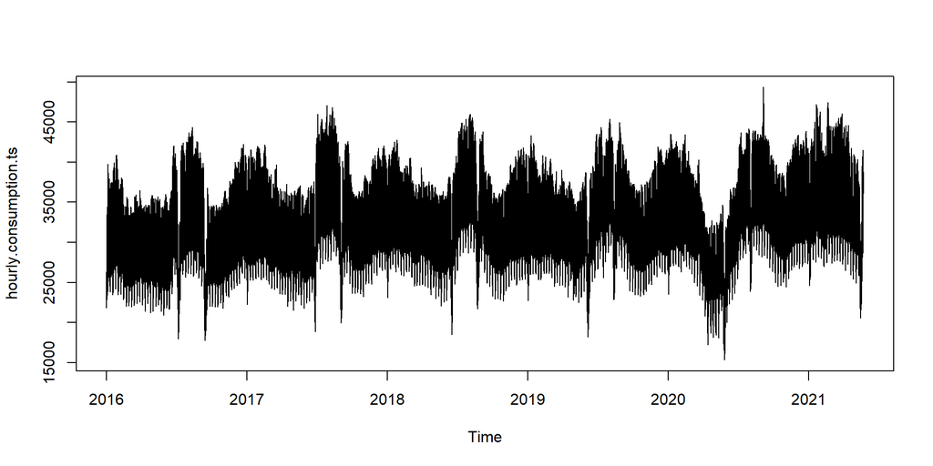

```r
hourly.consumption.ts <- ts(consumption$Consumption.MWh,  freq = 24*365, start= c(2016,1))
ts.plot(hourly.consumption.ts)
```

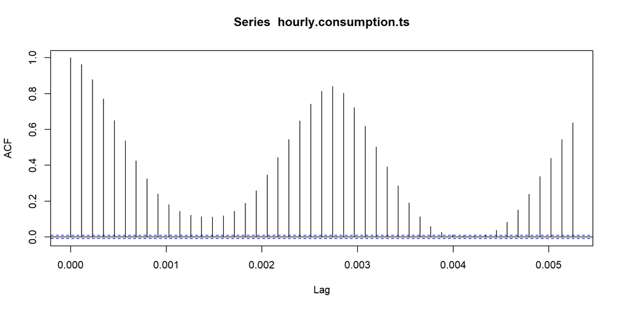

```r
acf(hourly.consumption.ts)
```

As we can see from `ts.plot()` plot, there is not much difference in the variance of the data. There is some particular outliers but it does not change too much the variance of the overall variance. Therefore, we can use `additive` decomposition.

As we can see from the `acf()` function, at every lag 24 autocovariance values have a peak.

Let us decompose the hourly time series object using `decompose()` function.

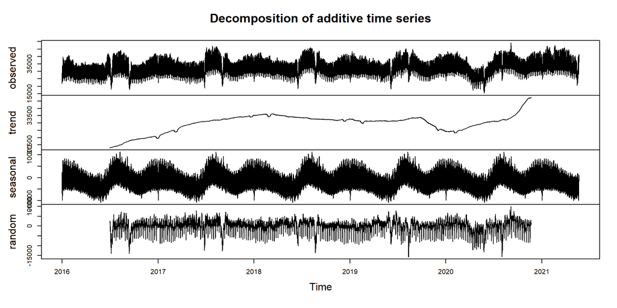

```r
hourly.consumption.dec.additive <- decompose(hourly.consumption.ts,type= "additive")

plot(hourly.consumption.dec.additive)
```

As we can see from random part of decomposited object, we can easily detect that there is still seasonality effect.

### Daily Data

In order to use daily information of our data, I take the mean of each 24 hours and build another data set called `daily_series`.

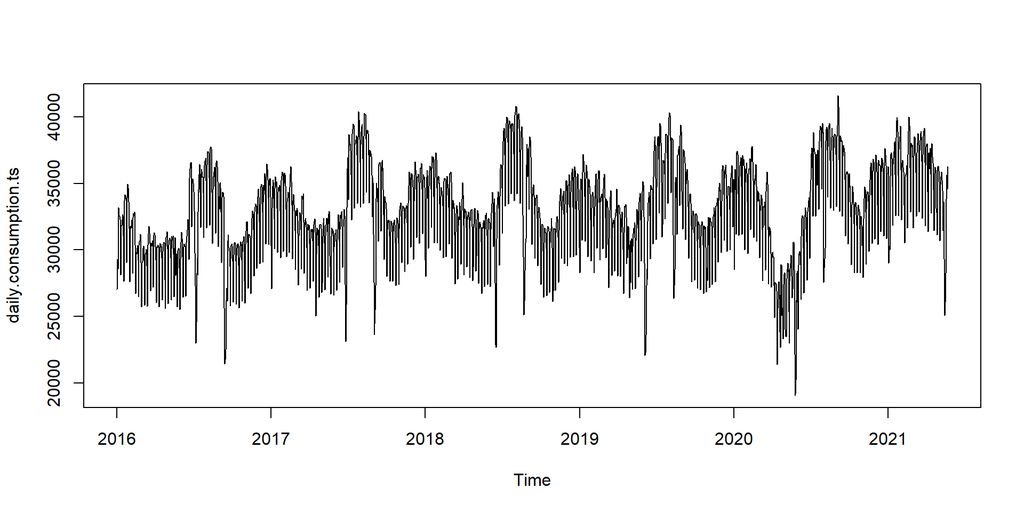

```r
daily_series= consumption[,list(Consumption.MWh=mean(Consumption.MWh)),by=list(Date)]

daily.consumption.ts <- ts(daily_series$Consumption.MWh,frequency = 365, start = c(2016,1))

ts.plot(daily.consumption.ts)
```

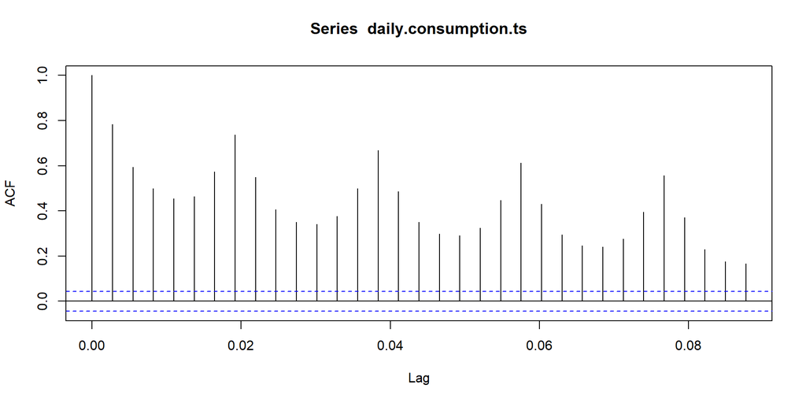

```r
acf(daily.consumption.ts)
```

As we can see, we have more clear `ts.plot()` plot, just because we take the mean of the hours to have a daily series.

Also `acf()` function shows us that there is peak in autocovariance values at each 7 lags which means there is also weekly seasonality in our data.

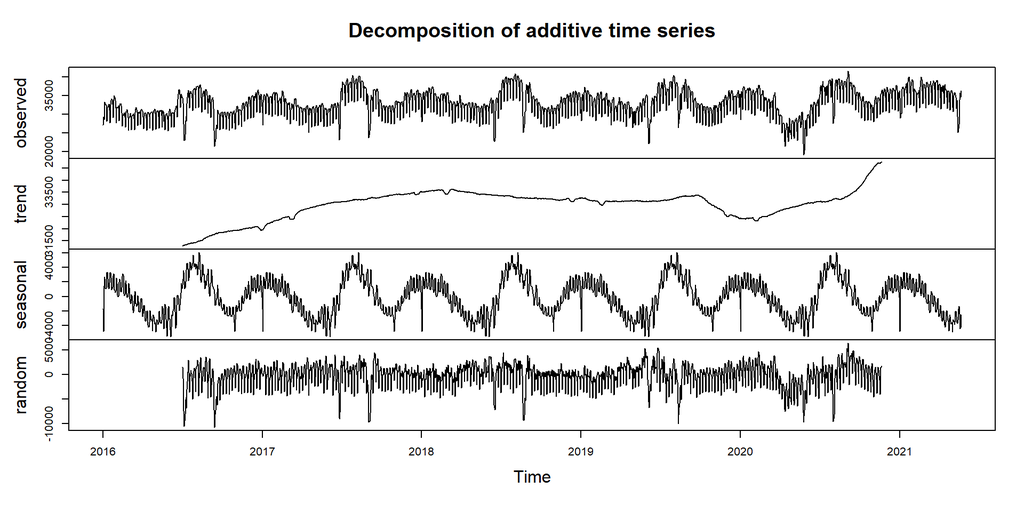

```r
daily.consumption.dec.additive <- decompose(daily.consumption.ts,type= "additive")
plot(daily.consumption.dec.additive)
```

There is nothing much changed after taking mean of the data to built a daily data, we still have fluctuations in seasonal term.

In random term, even if seasonality effect decreased compared to hourly data, there is still seasonality can be detected.

### Weekly Data

As we did to get a daily data, we will do the same thing to get a weekly data. Take the mean of the 7 days periods. Then we called that object as `weekly_series`

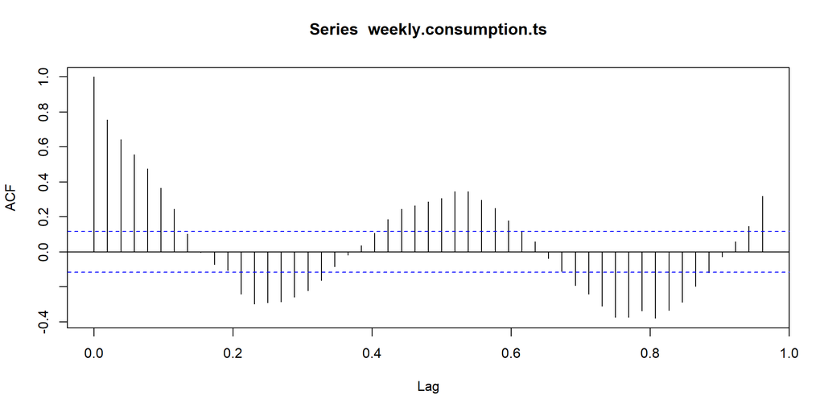

```r
weekly_series = aggregate( Consumption.MWh ~ week.number, consumption, mean)

weekly_date <-seq(as.Date("2016-01-04"), as.Date("2021-05-20"), by ="week")
first_week<- as.Date("2016-01-01")
weekly_date <- c(first_week,weekly_date)
weekly_series$weekly_date <-weekly_date

weekly.consumption.ts <- ts(weekly_series$Consumption.MWh, freq = 52, start = c(2016,1))
acf(weekly.consumption.ts,lag.max = 50)
```

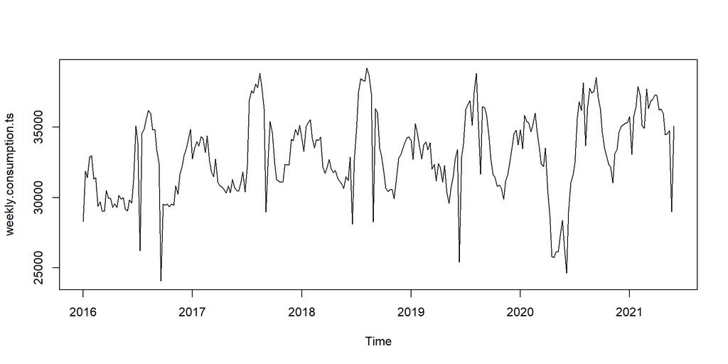

```r
ts.plot(weekly.consumption.ts)
```

As we can see from `acf()` function we still have seasonality in the lags 26, there is peak in autocovariance values.

In `ts.plot()` we have more clear plot, but we easily detect that particular time in the year there is peaks and dips.

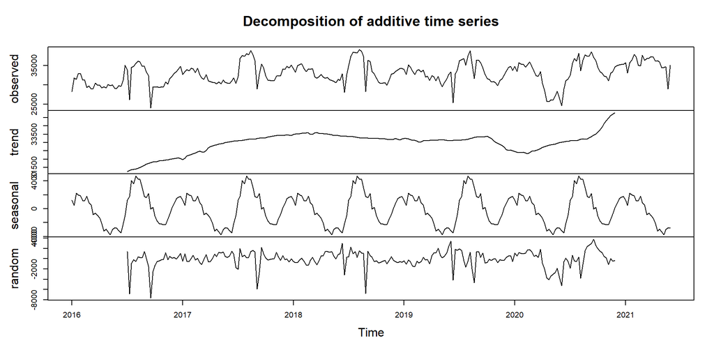

```r
weekly.consumption.dec.additive <- decompose(weekly.consumption.ts, type="additive")
plot(weekly.consumption.dec.additive)
```

We have now way more clear decomposited variables for both trend and seasonal variables. But random part of decomposited object have some outliers.

### Monthly Data

To decompose monthly data, I create `monthly_series` by taking mean of each month.

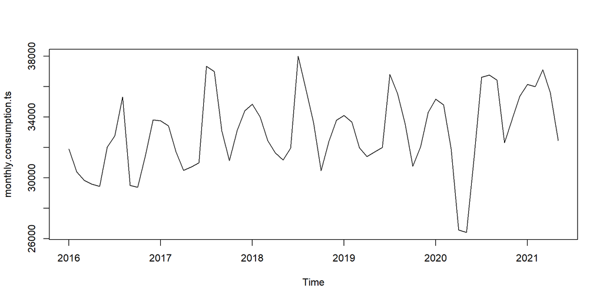

```r
monthly_series = aggregate( Consumption.MWh ~ Months + Year, consumption, mean)
monthly_dates <-seq(as.Date("2016-01-01"), as.Date("2021-05-20"), by ="month")
monthly_series$monthly_date <- monthly_dates

monthly.consumption.ts <- ts(monthly_series$Consumption.MWh, freq = 12, start = c(2016,1))
ts.plot(monthly.consumption.ts)
```

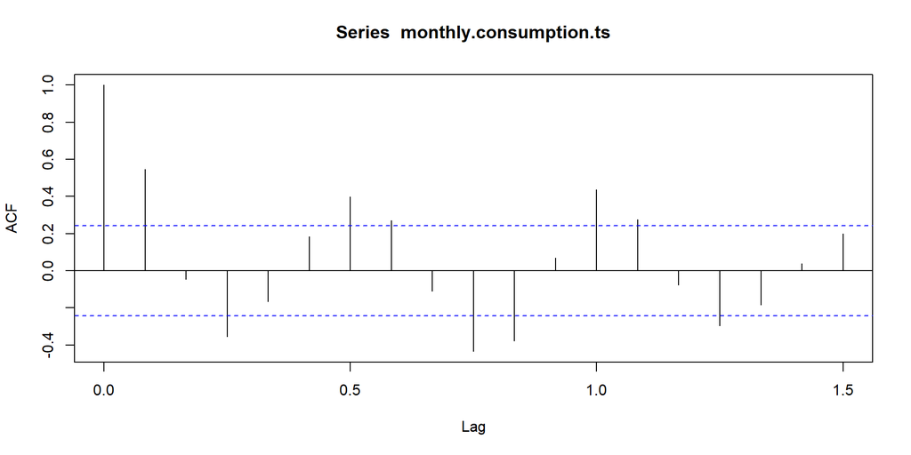

```r
acf(monthly.consumption.ts)
```

We can clearly see from both `acf()` and `ts.plot()` there is seasonality in the particular months of the year especially at lag6 and lag12.

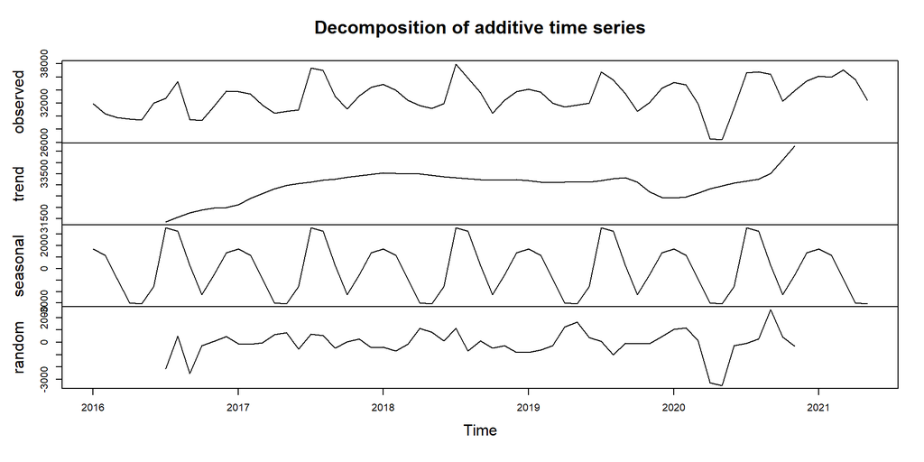

```r
monthly.consumption.dec.additive <- decompose(monthly.consumption.ts,type= "additive")
plot(monthly.consumption.dec.additive)
```

#### Conclusion for Different Time Units

For different time units, we decompose our data. While we increase our scope for time units, we get more clear and without fluctuations trend and seasonal terms.

However, there is still seasonality we detected even if we did for monthly data. Also there is outliers for every time unit.

### Weekly + Daily Data Decomposition

To use both daily and weekly seasonality, I applied two times decomposition into my data.

First, Lets check stationarity of the data for weekly seasonality with using `ur.kpss()` function.

```r
consumption[,differ:=Consumption.MWh - shift(Consumption.MWh,168)]
library(urca)
unt_test=ur.kpss(consumption$differ)
summary(unt_test)
```

```
##
## #######################
## # KPSS Unit Root Test #
## #######################
##
## Test is of type: mu with 18 lags.
##
## Value of test-statistic is: 0.052
##
## Critical value for a significance level of:
##                 10pct  5pct 2.5pct  1pct
## critical values 0.347 0.463  0.574 0.739
```

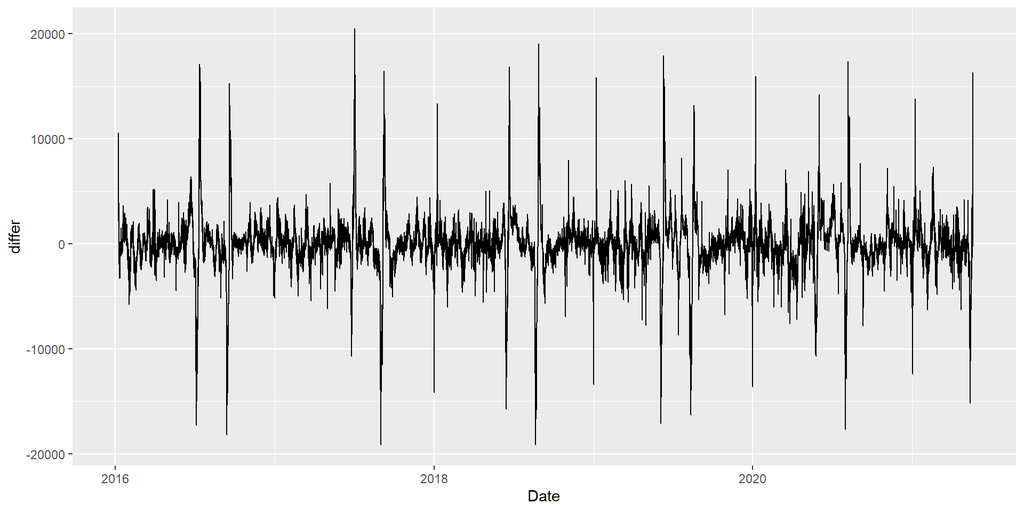

```r
ggplot(consumption,aes(x=Date)) + geom_line(aes(y=differ))
```

As we can see from ur.kpss() report, we found stationarity for our data because test-statistic value is small enough.

Also from plot, we can see briefly, we catch stationarity,but we have still outliers.

Now, before starting decompose our data, we should divide our data to training and test sets to do proper forecast. Our forecast is between ``07.05.2021` and `20.05.2021` for 14 days.

```r
training.consumption <- head(consumption$Consumption.MWh, length(consumption$Consumption.MWh) - 24*14)

test.consumption <- ts((tail(consumption$Consumption.MWh, (24*14 + 84 + 12))),
                       freq = 168 ,start=c(279,(168-84-12+1)) )

all.consumption.ts <- ts(consumption$Consumption.MWh, freq = 168)

weekly.ts <- ts(training.consumption,freq = 168)
```

Because we start with weekly seasonality, I built a time series object with frequency of 168 called `weekly.ts`.

As I mentioned before, because we don’t have too much variance in our data, we could use `additive` way to decompose our data.

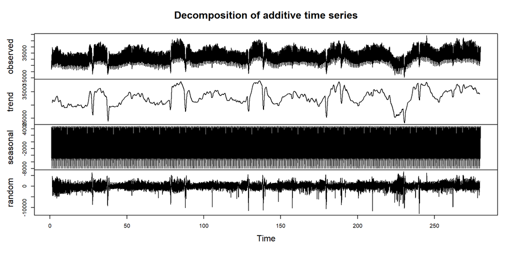

```r
weekly.decompose <- decompose(weekly.ts,type="additive")

plot(weekly.decompose)
```

To get only random part of the decomposited object, we should subtract `trend` and `seasonal` part.

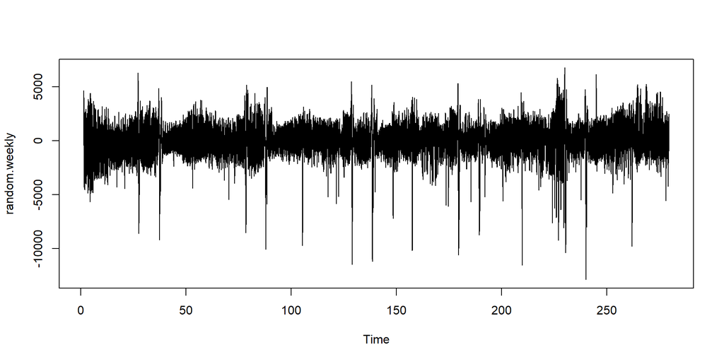

```r
deseason.weekly <- weekly.ts - weekly.decompose$seasonal
random.weekly <- deseason.weekly - weekly.decompose$trend
ts.plot(random.weekly)
```

So we have a random part of weekly data.

But we also want to decompose our data with regard to daily seasonality. Therefore, we apply second time decomposition to this `random.weekly`.

First, I should generate another time series object with frequency of 24 to be able to decompose as daily.

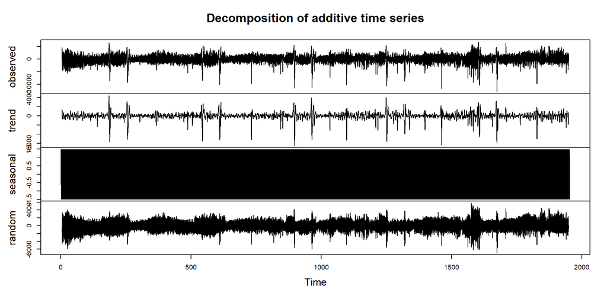

```r
weekly.daily.ts <- ts(random.weekly, freq = 24)

weekly.daily.decompose <- decompose(weekly.daily.ts,type="additive")

plot(weekly.daily.decompose)
```

Let’s subtract trend and seasonal part of it from `random.weekly`.

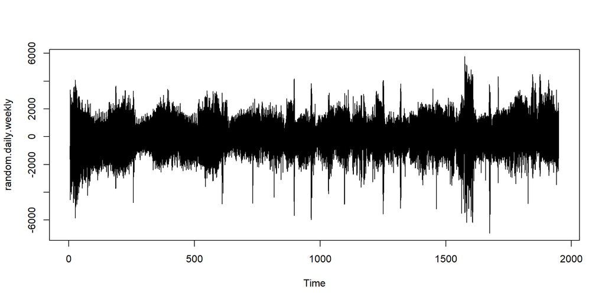

```r
deseason.daily.weekly <- weekly.daily.ts - weekly.daily.decompose$seasonal
random.daily.weekly <- deseason.daily.weekly - weekly.daily.decompose$trend

ts.plot(random.daily.weekly)
```

This plot looks very similar to `random.weekly` but this one has smaller values.

### Model Deciding (AR MODELS)

We are going to use our last decomposited random series which is `random.daily.weekly` to built our models.

As we see from tsplot of our `random.daily.weekly` data, we have a lot of outliers caused by holidays, religious and national days etc. I built in a csv file for that information. In that file we have 1’s for holidays and other special days and 0’s for normal days.

We are going to use this data in our models as a regressor to have a better knowledge about those outliers.

```r
resmitat <- read.csv("resmitat.csv")
consumption$ResmiTatil <- resmitat
training.resmitat <- head(consumption$ResmiTatil, length(consumption$ResmiTatil) - 24*14)
test.resmitat <- ts((tail(consumption$ResmiTatil, (24*14 + 84 + 12))), freq = 168, start=c(279,(168-84-12+1)) )
all.resmitat.ts <- ts(consumption$ResmiTatil, freq = 168)
```

Now we are ready to built our AR models.

Lets start with p = 1 for our first AR model.

```r
modelAR1 <- arima(random.daily.weekly, order=c(1,0,0),xreg= training.resmitat)
print(modelAR1)
```

```
##
## Call:
## arima(x = random.daily.weekly, order = c(1, 0, 0), xreg = training.resmitat)
##
## Coefficients:
##          ar1  intercept  training.resmitat
##       0.8666     7.1883          -171.2230
## s.e.  0.0023    20.5019            55.3721
##
## sigma^2 estimated as 344329:  log likelihood = -363798.8,  aic = 727605.7
```

As we can see our AIC error measure is pretty big, because we have some outliers and actually we have pretty big data set.

Because we are going to determine our model from their AIC values, I only print AIC values from now on.

```r
modelAR2 <- arima(random.daily.weekly, order=c(2,0,0),xreg= training.resmitat)
modelAR2$aic
```

```
## [1] 713432
```

We decreased AIC value a little bit.

```r
modelAR3 <- arima(random.daily.weekly, order=c(3,0,0),xreg= training.resmitat)
modelAR3$aic
```

```
## [1] 713393.7
```

We decreased very small amount of AIC value.

```r
modelAR4 <- arima(random.daily.weekly, order=c(10,0,0),xreg= training.resmitat)
modelAR4$aic
```

```
## [1] 709981.8
```

We decreased very tiny amount of AIC value even if I increased p value too much. To be effective and, to get rid of computation problems, we stop here for Auto Regressive Models.

### Model Deciding (MA MODELS)

To built Moving Average Models, we should determine q parameter.

Let us start with q = 1

```r
modelMA1 <- arima(random.daily.weekly, order=c(0,0,1),xreg= training.resmitat)
modelMA1$aic
```

```
## [1] 746072.2
```

Now, we have higher AIC values compared to our first `MA1` model which has p = 1. So lets increase q value one more.

```r
modelMA2 <- arima(random.daily.weekly, order=c(0,0,2),xreg= training.resmitat)
modelMA2$aic
```

```
## [1] 728560.5
```

Here, also we decreased AIC value a little bit.

```r
modelMA3 <- arima(random.daily.weekly, order=c(0,0,10),xreg= training.resmitat)
modelMA3$aic
```

```
## [1] 708740.8
```

Because we have little improvement in MA models, computation problems and to be effective, we stopped here for Moving Average Models.

### Model Deciding (ARIMA MODELS)

Lets give a shot to `p = 1` and `d = 1`

```r
modelARIMA1 <- arima(random.daily.weekly, order=c(1,1,0),xreg= training.resmitat)
modelARIMA1$aic
```

```
## [1] 722174.4
```

It is a good start for the first model. Lets keep increase the coefficients.

```r
modelARIMA2 <- arima(random.daily.weekly, order=c(1,1,1),xreg= training.resmitat)
modelARIMA2$aic
```

```
## [1] 721175.9
```

AIC value improved but this amount is very small. So here we dropped `d` coefficient to see how ARIMA behave.

```r
modelARIMA3 <- arima(random.daily.weekly, order=c(1,0,1),xreg= training.resmitat)
modelARIMA3$aic
```

```
## [1] 715893
```

Now, we have decrease a lot. We can conclude that `d` coefficient stand for differencing and it is nothing to do with our model because we already decompose our data.

Keep increase `p` and `d` coefficient to find a better model.

```r
modelARIMA4 <- arima(random.daily.weekly, order=c(4,0,4),xreg= training.resmitat)
modelARIMA4$aic
```

```
## [1] 702156.5
```

We have good improvement in AIC value compared to other values. We can increase one more for both `p` and `q`.

```r
modelARIMA5 <- arima(random.daily.weekly, order=c(5,0,5),xreg= training.resmitat)
modelARIMA5$aic
```

```
## [1] 701623.3
```

```r
modelARIMA6 <- arima(random.daily.weekly, order=c(4,0,5),xreg= training.resmitat)
modelARIMA6$aic
```

```
## [1] 701780.2
```

```r
modelARIMA7 <- arima(random.daily.weekly, order=c(5,0,4),xreg= training.resmitat)
modelARIMA7$aic
```

```
## [1] 701656.4
```

```r
print( modelARIMA7)
```

```
##
## Call:
## arima(x = random.daily.weekly, order = c(5, 0, 4), xreg = training.resmitat)
##
## Coefficients:
##          ar1      ar2     ar3      ar4     ar5     ma1    ma2      ma3      ma4
##       0.8234  -0.1297  0.9086  -0.8963  0.0413  0.3379  3e-04  -0.9768  -0.3615
## s.e.  0.0125   0.0108  0.0017   0.0115  0.0118  0.0115  1e-03   0.0013   0.0116
##       intercept  training.resmitat
##          0.0310            -0.6851
## s.e.     0.0266             0.5867
##
## sigma^2 estimated as 197373:  log likelihood = -350816.2,  aic = 701656.4
```

But when we look at resmitatil regressor in the model, it does not have a lot of effect in the model.

### Adding Decomposoted Parts

Now to do proper forecast, we should add parts that we subtracted to built our ARIMA models to the residuals of `modelARIMA7`.

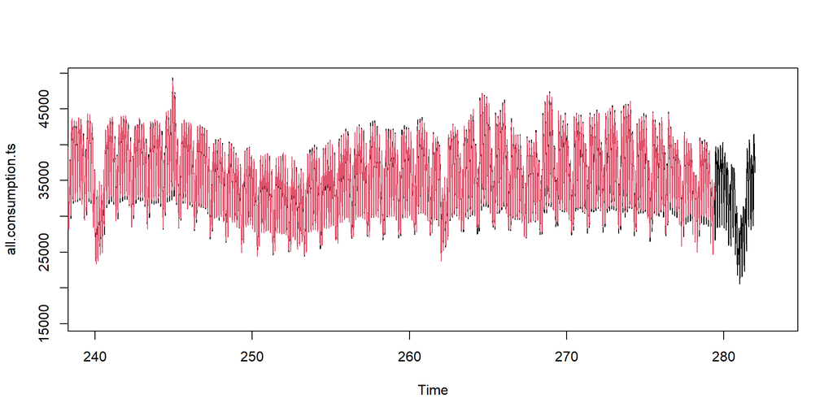

```r
model_fitted <- random.daily.weekly - residuals(modelARIMA7)
model_fitted_transformed <- model_fitted + weekly.daily.decompose$trend + weekly.daily.decompose$seasonal
model_fitted_transformed <- ts(model_fitted_transformed,freq = 168)
model_fitted_transformed <- model_fitted_transformed + weekly.decompose$trend + weekly.decompose$seasonal

plot(all.consumption.ts, xlim = c(240,283))
points(model_fitted_transformed, type= "l", col = 2,xlim = c(240,283))
```

Here, we see our model is fitted. For the last part, lets forecast!

### Forecast

Now, we should determine how many time units ahead we are going to forecast.

While we decompose our data set, we lose some data. For daily decomposition we lost `24/2 = 12` and for weekly decomposition we lost `(24*7) / 2 = 84`. Therefore, we lost `84 + 12 = 96` data points. These data points is not included in our model. Therefore, we also need them to be forecasted.

We also want to do our forecast for 14 days.

Overall forecast ahead time is `14 * 24 + 96 = 432`.

We can use `predict()` function to forecast.

```r
model.forecast <- predict(modelARIMA7, n.ahead = 432, newxreg = test.resmitat)$pred
model.forecast= ts(model.forecast, frequency = 168, start=c(279,(168-84-12+1)))
```

We also need to add trend and seasonal part. We are going to use the last values of trends in decomposed objects and add them up.

```r
last.trend.value <-tail(weekly.decompose$trend[!is.na(weekly.decompose$trend)],432) + tail(weekly.daily.decompose$trend[!is.na(weekly.daily.decompose$trend)],432)
```

For the seasonal parts, all season have the same coefficient therefore we take corresponding points for the first days of the decomposed object.

```r
seasonality=weekly.daily.decompose$seasonal[97:528] + weekly.decompose$seasonal[97:528]
```

Now we should add our forecasts seasonal coefficients and last trend values together.

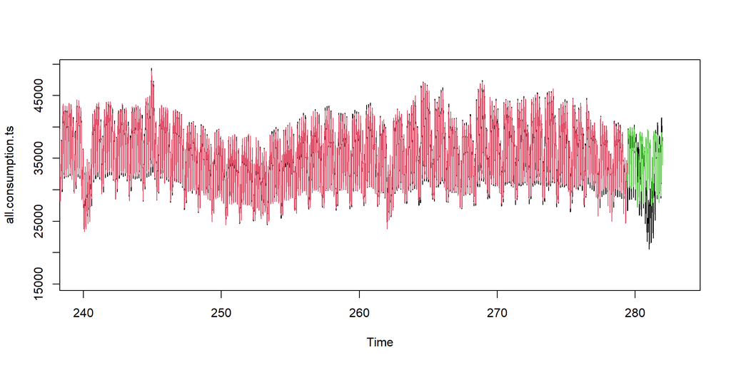

```r
model.forecast.last = model.forecast + last.trend.value + seasonality


plot(all.consumption.ts, xlim = c(240,283))
points(model_fitted_transformed, type= "l", col = 2,xlim = c(240,283))
points(model.forecast.last, type = "l", col = 3)
```

Here is our forecast in green, we don’t have very good prediction as you can see. Because we don’t have a lot of affect on our models about the national, religious or special holidays. In May 12 to May 15 2021, we have Ramadan Bairam. Therefore, our prediction, does not did well.

However, lets compute different error measures.

### Error Calculations

To compute error measures, I took last 14 days of our actual data to the data table called `tested.data` and add this table our forecasts.

```r
tested.data <- tail(consumption, 24*14)
daily.model.forecast = ts(model.forecast.last,freq= 24)
daily.model.forecast <- daily.model.forecast[-c(1:96)]
tested.data$daily.model.forecast <- daily.model.forecast
```

#### Daily Bias and Daily Mean Absolute Percentage Error

Here, computation of daily bias and MAPE:

```r
errors <- tested.data[,list( MAPE = sum(abs((daily.model.forecast
                                             - Consumption.MWh)/Consumption.MWh))/24,
                             daily.bias = sum(Consumption.MWh - daily.model.forecast)/24),
                      by= list(Date)]

print(errors)
```

```
##           Date       MAPE  daily.bias
##  1: 2021-05-07 0.03928713    484.2175
##  2: 2021-05-08 0.09374151   3267.6564
##  3: 2021-05-09 0.15977956  -3683.8785
##  4: 2021-05-10 0.07853420  -2133.6247
##  5: 2021-05-11 0.05701976     86.2393
##  6: 2021-05-12 0.21072177  -5342.6029
##  7: 2021-05-13 0.43631766 -10844.9688
##  8: 2021-05-14 0.34527461  -8801.5666
##  9: 2021-05-15 0.15692360  -4120.7584
## 10: 2021-05-16 0.25306212  -7062.4722
## 11: 2021-05-17 0.07814899  -1814.7290
## 12: 2021-05-18 0.04244801    495.5600
## 13: 2021-05-19 0.04529928    617.9932
## 14: 2021-05-20 0.04789058    872.9718
```

#### Weighted Mean Absolute Percentage Error

For 14-days period, I calculate mean of daily consumption and daily forecast.

```r
daily.mean.comparison.data <-tested.data[,list(mean.consumption = mean(Consumption.MWh,na.rm=T), mean.forecast = mean(daily.model.forecast,na.rm=T)), by=list(Date)]

WMAPE <- sum(abs((daily.mean.comparison.data$mean.consumption- daily.mean.comparison.data$mean.forecast)))/ sum(daily.mean.comparison.data$mean.consumption) * 100

WMAPE
```

```
## [1] 11.16678
```

We have 11% error overall, which is not acceptable, I think.

### Conclusion

As we can see from all the error measures, we have to teach our model about the special days, national and religious holidays etc. in some way. We should have significant effect of a regressor about those special days in our model. Just by checking AIC measaure we don’t did very well in our forecast.

### References

[EPIAS Seffaflik Platformu](https://seffaflik.epias.com.tr/transparency/)